# ADVANCED STATISTICS FOR FINANCE EXAM - DATASET: MOVIES

MATTIA MARSANO

18 JUNE 2026

This project analyzes the movies.csv dataset, which contains information about movies such as “budget”, “gross revenue”, “runtime”, “score”, “votes” and “year” of release. The main objective is to study the relationship between movie revenue and the available numerical variables using multiple linear regression. The analysis also includes missing data cleaning, model selection through forward and backward stepwise selection, and an evaluation of the final model on a test set.

# 1) LOADING THE DATA INTO R

```r
movies <- read.csv("movies.csv")

dim(movies)
```

```
## [1] 7668   15
```

```r
View(movies)
names(movies)
```

```
##  [1] "name"     "rating"   "genre"    "year"     "released" "score"
##  [7] "votes"    "director" "writer"   "star"     "country"  "budget"
## [13] "gross"    "company"  "runtime"
```

```r
summary(movies)
```

```
##      name              rating             genre                year
##  Length:7668        Length:7668        Length:7668        Min.   :1980
##  Class :character   Class :character   Class :character   1st Qu.:1991
##  Mode  :character   Mode  :character   Mode  :character   Median :2000
##                                                           Mean   :2000
##                                                           3rd Qu.:2010
##                                                           Max.   :2020
##
##    released             score          votes           director
##  Length:7668        Min.   :1.90   Min.   :      7   Length:7668
##  Class :character   1st Qu.:5.80   1st Qu.:   9100   Class :character
##  Mode  :character   Median :6.50   Median :  33000   Mode  :character
##                     Mean   :6.39   Mean   :  88109
##                     3rd Qu.:7.10   3rd Qu.:  93000
##                     Max.   :9.30   Max.   :2400000
##                     NA's   :3      NA's   :3
##     writer              star             country              budget
##  Length:7668        Length:7668        Length:7668        Min.   :     3000
##  Class :character   Class :character   Class :character   1st Qu.: 10000000
##  Mode  :character   Mode  :character   Mode  :character   Median : 20500000
##                                                           Mean   : 35589876
##                                                           3rd Qu.: 45000000
##                                                           Max.   :356000000
##                                                           NA's   :2171
##      gross             company             runtime
##  Min.   :3.090e+02   Length:7668        Min.   : 55.0
##  1st Qu.:4.532e+06   Class :character   1st Qu.: 95.0
##  Median :2.021e+07   Mode  :character   Median :104.0
##  Mean   :7.850e+07                      Mean   :107.3
##  3rd Qu.:7.602e+07                      3rd Qu.:116.0
##  Max.   :2.847e+09                      Max.   :366.0
##  NA's   :189                            NA's   :4
```

# 2) MISSING DATA

First I count the missing values and then remove the observations that have at least one of them.

```r
initial.n.rows <- dim(movies)[1]
initial.n.rows
```

```
## [1] 7668
```

```r
sum(is.na(movies))
```

```
## [1] 2370
```

```r
movies.without.na <- na.omit(movies)
dim(movies.without.na)
```

```
## [1] 5435   15
```

```r
sum(is.na(movies.without.na))
```

```
## [1] 0
```

Since in the description of the file it is written that “budget” equal to 0 means missing, I put these values equal to “NA” and then remove them (even though in this specific case there are no observations in “budget” that are 0 but I decided to do it anyway to show the procedure with the codes).

```r
sum(movies.without.na$budget == 0)
```

```
## [1] 0
```

```r
movies.without.na$budget[movies.without.na$budget == 0] <- NA
sum(is.na(movies.without.na))
```

```
## [1] 0
```

```r
movies.cleaned <- na.omit(movies.without.na)
dim(movies.cleaned)
```

```
## [1] 5435   15
```

```r
sum(is.na(movies.cleaned))
```

```
## [1] 0
```

```r
final.n.rows <- dim(movies.cleaned)[1]
final.n.rows
```

```
## [1] 5435
```

Finally, the percentage of observations removed is:

```r
missing.percentage <- 100 * (initial.n.rows - final.n.rows) / initial.n.rows
missing.percentage
```

```
## [1] 29.12102
```

# 3) SCATTERPLOT

I consider the variables “score” and “budget” (expressed in millions).

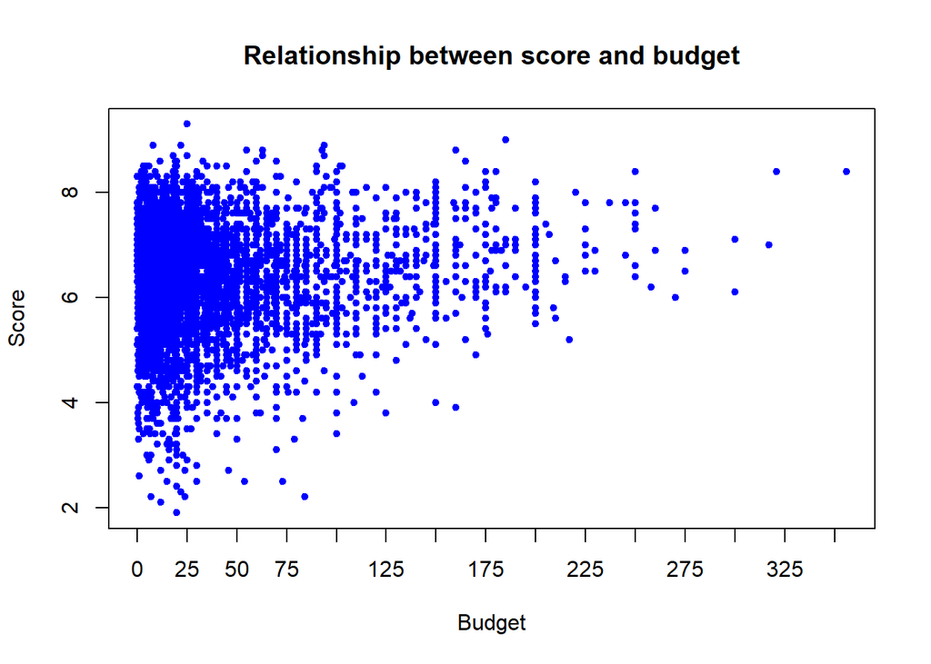

```r
plot(movies.cleaned$budget/1000000, movies.cleaned$score,
     xlab = "Budget",
     ylab = "Score",
     main = "Relationship between score and budget",
     pch = 20,
     col = "blue",
     xaxt = "n")
axis(1, at = seq(0, 350, by = 25))
```

The scatterplot shows that there is not a strong linear relationship between “budget” and “score”.Most movies are concentrated in the left part of the graph, meaning that many films have relatively low budgets compared to the few movies with very high budgets. The points are quite dispersed, so there is not a strong linear relationship between budget and score. In general, movies with higher budgets do not necessarily obtain higher scores.

# 4) MULTIPLE LINEAR REGRESSION

```r
lm.full <- lm(gross ~ budget + runtime + score + votes + year,
              data = movies.cleaned)
summary(lm.full)
```

```
##
## Call:
## lm(formula = gross ~ budget + runtime + score + votes + year,
##     data = movies.cleaned)
##
## Residuals:
##        Min         1Q     Median         3Q        Max
## -864635813  -37311489      35485   25404962 1869626170
##
## Coefficients:
##               Estimate Std. Error t value Pr(>|t|)
## (Intercept) -3.021e+08  3.015e+08  -1.002 0.316445
## budget       2.688e+00  4.374e-02  61.445  < 2e-16 ***
## runtime     -5.543e+05  9.583e+04  -5.784  7.7e-09 ***
## score        6.505e+06  1.905e+06   3.414 0.000645 ***
## votes        3.592e+02  1.042e+01  34.472  < 2e-16 ***
## year         1.427e+05  1.506e+05   0.948 0.343376
## ---
## Signif. codes:  0 '***' 0.001 '**' 0.01 '*' 0.05 '.' 0.1 ' ' 1
##
## Residual standard error: 110100000 on 5429 degrees of freedom
## Multiple R-squared:  0.6542, Adjusted R-squared:  0.6539
## F-statistic:  2054 on 5 and 5429 DF,  p-value: < 2.2e-16
```

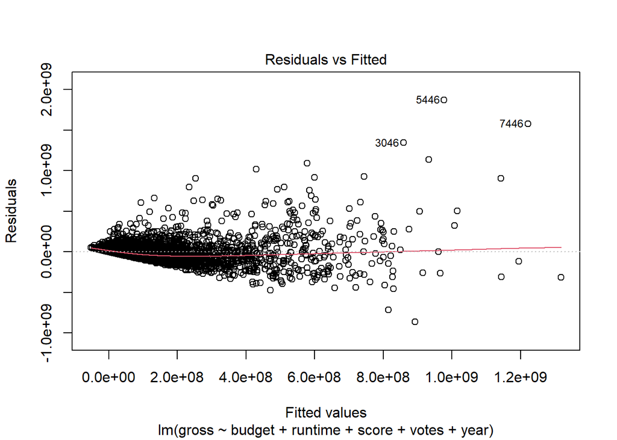

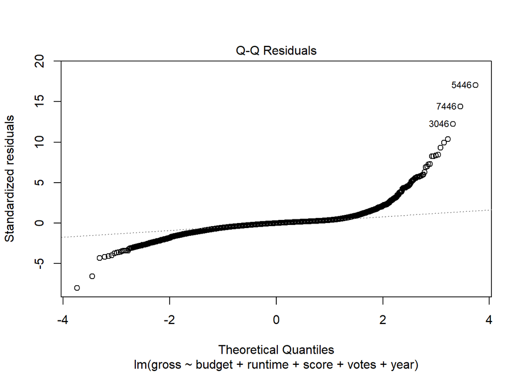

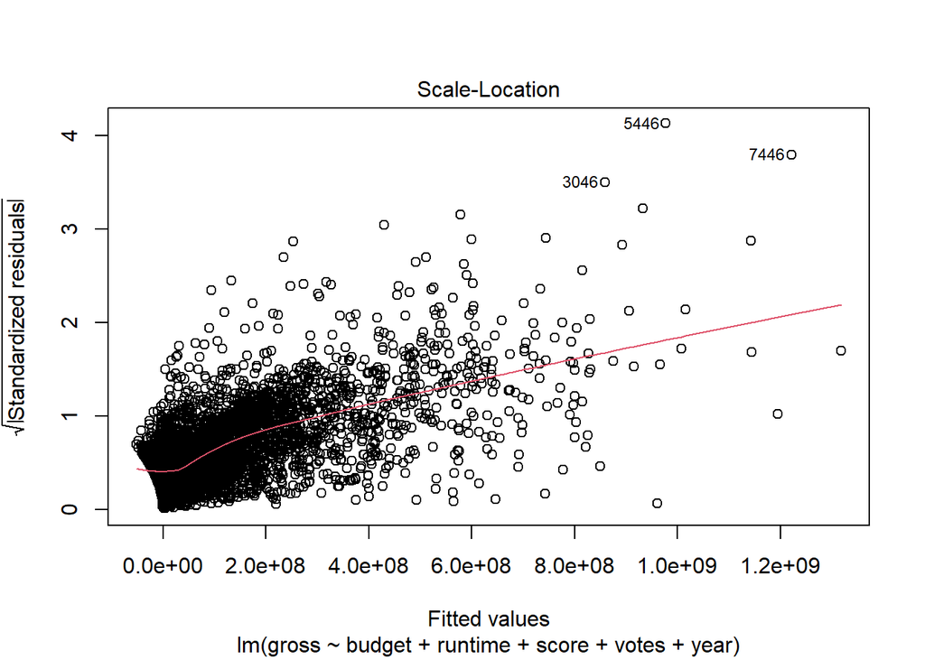

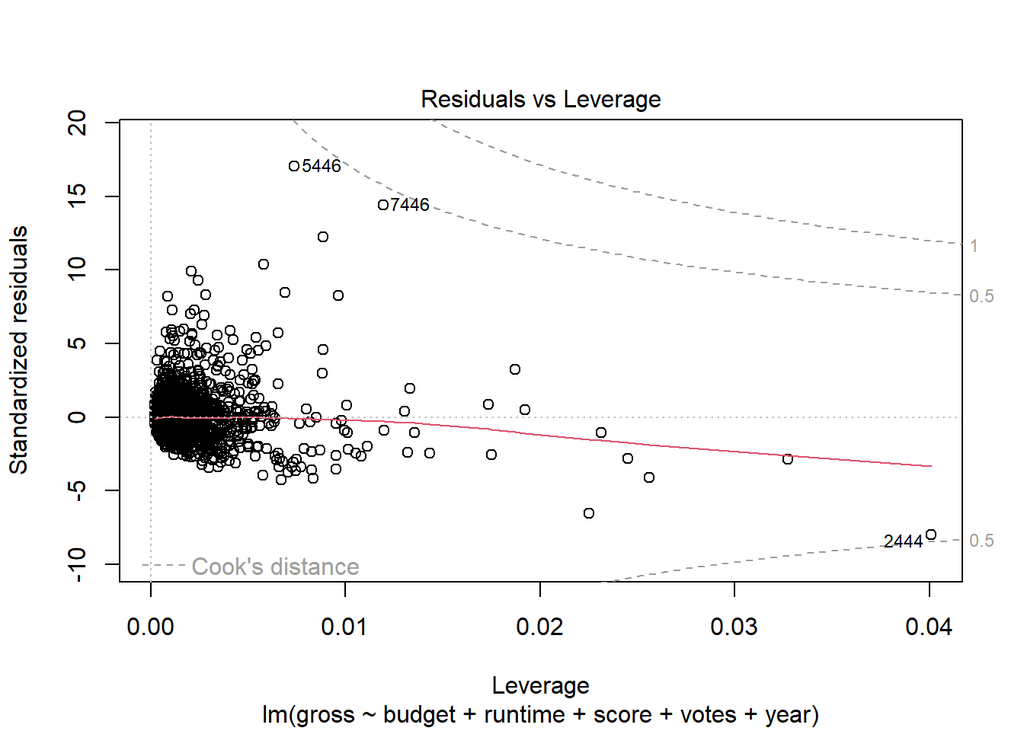

```r
plot(lm.full)  #reminder: heteroschedasticity
```

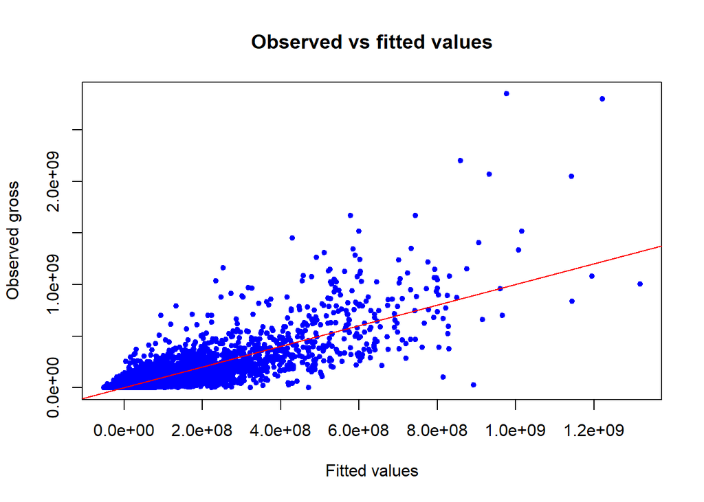

```r
plot(fitted(lm.full), movies.cleaned$gross,
     xlab = "Fitted values",
     ylab = "Observed gross",
     main = "Observed vs fitted values",
     pch = 20,
     col = "blue")

abline(0, 1, col = "red")
```

# 5) FORWARD STEPWISE SELECTION

I use Forward Stepwise Selection with the function “regsubsets()”.

```r
library(leaps)
regfit.forward <- regsubsets(gross ~ budget + runtime + score + votes + year,
                         data = movies.cleaned,
                         nvmax = 5,
                         method = "forward")

summary(regfit.forward)
```

```
## Subset selection object
## Call: regsubsets.formula(gross ~ budget + runtime + score + votes +
##     year, data = movies.cleaned, nvmax = 5, method = "forward")
## 5 Variables  (and intercept)
##         Forced in Forced out
## budget      FALSE      FALSE
## runtime     FALSE      FALSE
## score       FALSE      FALSE
## votes       FALSE      FALSE
## year        FALSE      FALSE
## 1 subsets of each size up to 5
## Selection Algorithm: forward
##          budget runtime score votes year
## 1  ( 1 ) "*"    " "     " "   " "   " "
## 2  ( 1 ) "*"    " "     " "   "*"   " "
## 3  ( 1 ) "*"    "*"     " "   "*"   " "
## 4  ( 1 ) "*"    "*"     "*"   "*"   " "
## 5  ( 1 ) "*"    "*"     "*"   "*"   "*"
```

```r
reg.summary.forward <- summary(regfit.forward)
names(reg.summary.forward)
```

```
## [1] "which"  "rsq"    "rss"    "adjr2"  "cp"     "bic"    "outmat" "obj"
```

To check manually and understand better (and practically) how the Forward Stepwise Selection works. We can see that the best 2-regressor model (which minimize the RSS)is the third using “votes” after “budget”. This is the mechanism that explain the * in the results of the previous chunk and it is repeated also with the other variables.

```r
lm1 <- lm(gross ~ budget + runtime, data = movies.cleaned)
lm2 <- lm(gross ~ budget + score, data = movies.cleaned)
lm3 <- lm(gross ~ budget + votes, data = movies.cleaned)
lm4 <- lm(gross ~ budget + year, data = movies.cleaned)

sum(resid(lm1)^2)
```

```
## [1] 8.562702e+19
```

```r
sum(resid(lm2)^2)
```

```
## [1] 8.050349e+19
```

```r
sum(resid(lm3)^2)
```

```
## [1] 6.624169e+19
```

```r
sum(resid(lm4)^2)
```

```
## [1] 8.574728e+19
```

I look at adjusted R squared, Cp and BIC.

```r
summary(regfit.forward)$cp
```

```
## [1] 1662.585080   37.337387   14.668975    4.897943    6.000000
```

```r
which.min(reg.summary.forward$cp)
```

```
## [1] 4
```

```r
summary(regfit.forward)$bic
```

```
## [1] -4301.075 -5708.738 -5724.720 -5727.889 -5720.187
```

```r
which.min(reg.summary.forward$bic)
```

```
## [1] 4
```

```r
summary(regfit.forward)$adjr2
```

```
## [1] 0.5481238 0.6517188 0.6532266 0.6539130 0.6539065
```

```r
which.max(reg.summary.forward$adjr2)
```

```
## [1] 4
```

The model selected by BIC is:

```r
best.forward <- which.min(reg.summary.forward$bic)
best.forward
```

```
## [1] 4
```

```r
coef(regfit.forward, best.forward)
```

```
##   (Intercept)        budget       runtime         score         votes
## -1.661919e+07  2.699033e+00 -5.593788e+05  6.535757e+06  3.598566e+02
```

# 6) BACKWARD STEPWISE SELECTION

Now I repeat the same thing with Backward Stepwise Selection.

```r
regfit.backward <- regsubsets(gross ~ budget + runtime + score + votes + year,
                         data = movies.cleaned,
                         nvmax = 5,
                         method = "backward")
summary(regfit.backward)
```

```
## Subset selection object
## Call: regsubsets.formula(gross ~ budget + runtime + score + votes +
##     year, data = movies.cleaned, nvmax = 5, method = "backward")
## 5 Variables  (and intercept)
##         Forced in Forced out
## budget      FALSE      FALSE
## runtime     FALSE      FALSE
## score       FALSE      FALSE
## votes       FALSE      FALSE
## year        FALSE      FALSE
## 1 subsets of each size up to 5
## Selection Algorithm: backward
##          budget runtime score votes year
## 1  ( 1 ) "*"    " "     " "   " "   " "
## 2  ( 1 ) "*"    " "     " "   "*"   " "
## 3  ( 1 ) "*"    "*"     " "   "*"   " "
## 4  ( 1 ) "*"    "*"     "*"   "*"   " "
## 5  ( 1 ) "*"    "*"     "*"   "*"   "*"
```

```r
reg.summary.backward <- summary(regfit.backward)
```

Again, I look at adjusted R squared, Cp and BIC.

```r
summary(regfit.backward)$cp
```

```
## [1] 1662.585080   37.337387   14.668975    4.897943    6.000000
```

```r
which.min(reg.summary.backward$cp)
```

```
## [1] 4
```

```r
summary(regfit.backward)$bic
```

```
## [1] -4301.075 -5708.738 -5724.720 -5727.889 -5720.187
```

```r
which.min(reg.summary.backward$bic)
```

```
## [1] 4
```

```r
summary(regfit.backward)$adjr2
```

```
## [1] 0.5481238 0.6517188 0.6532266 0.6539130 0.6539065
```

```r
which.max(reg.summary.backward$adjr2)
```

```
## [1] 4
```

The model selected by BIC is:

```r
best.backward <- which.min(reg.summary.backward$bic)
best.backward
```

```
## [1] 4
```

```r
coef(regfit.backward, best.backward)
```

```
##   (Intercept)        budget       runtime         score         votes
## -1.661919e+07  2.699033e+00 -5.593788e+05  6.535757e+06  3.598566e+02
```

# 7) COMPARISON

I compare the coefficients and the BIC values of the two selected models.

```r
coef(regfit.forward, best.forward)
```

```
##   (Intercept)        budget       runtime         score         votes
## -1.661919e+07  2.699033e+00 -5.593788e+05  6.535757e+06  3.598566e+02
```

```r
coef(regfit.backward, best.backward)
```

```
##   (Intercept)        budget       runtime         score         votes
## -1.661919e+07  2.699033e+00 -5.593788e+05  6.535757e+06  3.598566e+02
```

```r
reg.summary.forward$bic[best.forward]
```

```
## [1] -5727.889
```

```r
reg.summary.backward$bic[best.backward]
```

```
## [1] -5727.889
```

The forward and backward stepwise selection procedures select the same final model including “budget”, “runtime”, “score” and “votes” and excluding “year”. Since the selected predictors are the same, the estimated coefficients and the BIC values are identical. This suggests that the selected model is stable with respect to the selection method.

Running a regression without the variable “year”

```r
lm.final.all <- lm(gross ~ budget + runtime + score + votes, data = movies.cleaned)
summary(lm.final.all)
```

```
##
## Call:
## lm(formula = gross ~ budget + runtime + score + votes, data = movies.cleaned)
##
## Residuals:
##        Min         1Q     Median         3Q        Max
## -867045834  -37081682      93184   24787252 1867992930
##
## Coefficients:
##               Estimate Std. Error t value Pr(>|t|)
## (Intercept) -1.662e+07  1.262e+07  -1.317 0.187884
## budget       2.699e+00  4.211e-02  64.097  < 2e-16 ***
## runtime     -5.594e+05  9.567e+04  -5.847 5.31e-09 ***
## score        6.536e+06  1.905e+06   3.431 0.000606 ***
## votes        3.599e+02  1.040e+01  34.615  < 2e-16 ***
## ---
## Signif. codes:  0 '***' 0.001 '**' 0.01 '*' 0.05 '.' 0.1 ' ' 1
##
## Residual standard error: 110100000 on 5430 degrees of freedom
## Multiple R-squared:  0.6542, Adjusted R-squared:  0.6539
## F-statistic:  2568 on 4 and 5430 DF,  p-value: < 2.2e-16
```

In the full multiple linear regression model (the initial one: lm.full), the variable “year” has a p-value of about 0.343. Since this value is much larger than the usual significance level of 0.05, “year” is not statistically significant after controlling for “budget”, “runtime”, “score” and “votes”. This means that, once the other numerical predictors are included in the model, “year” does not seem to have a relevant individual effect on “gross”. This result is also confirmed by the comparison between the full model and the reduced model without “year”. Therefore, is it preferred the model without “year” (the final one: lm.final.all), since it gives almost the same explanatory power but with fewer variables.

# 8) TRANING SET, TEST SET AND MSE

I split the data into a training set and a test set. The training set contains about 70 percent of the observations.

```r
set.seed(1234)
train <- sample(1:nrow(movies.cleaned), 0.7 * nrow(movies.cleaned))
test <- (-train)

movies.train <- movies.cleaned[train, ]
movies.test <- movies.cleaned[test, ]

dim(movies.train)
```

```
## [1] 3804   15
```

```r
dim(movies.test)
```

```
## [1] 1631   15
```

I fit the final model on the training set.

```r
lm.train <- lm(gross ~ budget + runtime + score + votes, data = movies.train)
summary(lm.train)
```

```
##
## Call:
## lm(formula = gross ~ budget + runtime + score + votes, data = movies.train)
##
## Residuals:
##        Min         1Q     Median         3Q        Max
## -867952239  -36814152     101510   24870826 1859376979
##
## Coefficients:
##               Estimate Std. Error t value Pr(>|t|)
## (Intercept) -2.774e+07  1.568e+07  -1.769  0.07696 .
## budget       2.719e+00  5.198e-02  52.306  < 2e-16 ***
## runtime     -4.627e+05  1.179e+05  -3.924 8.87e-05 ***
## score        6.627e+06  2.350e+06   2.821  0.00482 **
## votes        3.586e+02  1.278e+01  28.065  < 2e-16 ***
## ---
## Signif. codes:  0 '***' 0.001 '**' 0.01 '*' 0.05 '.' 0.1 ' ' 1
##
## Residual standard error: 1.14e+08 on 3799 degrees of freedom
## Multiple R-squared:  0.6426, Adjusted R-squared:  0.6423
## F-statistic:  1708 on 4 and 3799 DF,  p-value: < 2.2e-16
```

Then I predict “gross” on the test set and compute the mean squared error.

```r
pred.final <- predict(lm.train, movies.test)
mse.final <- mean((movies.test$gross - pred.final)^2)
mse.final
```

```
## [1] 1.007738e+16
```

The value “mse.final” is the test mean squared error of my final model. The RMSE is about 100 million, meaning that the typical prediction error on the test set is around 100 million in gross revenue. This is quite large, but it is reasonable given the high variability of movie revenues and the presence of outliers. Therefore, the model has some predictive ability, but its predictions are still affected by substantial uncertainty.